# T06. Genética de poblaciones

2024-10-10

## La pregunta de Yule

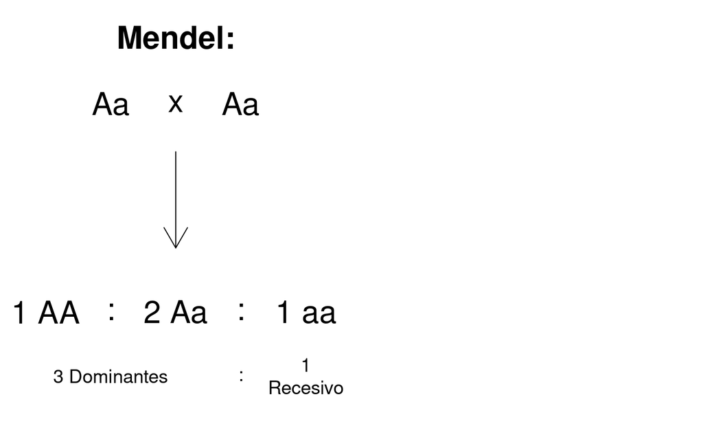

> “Pero, si la braquidactilia estuviera determinada per un alelo dominante y si el apareamiento fuera aleatorio, esperaríamos tres personas con braquidactilia por cada persona normal, ¿no?”

## Desafíos intelectuales en 1908

- ¿Cómo cambian las frecuencias *genotípicas* con el tiempo?
  - De cruces controlados a reproducción aleatoria.
- ¿Qué importancia tiene la *dominancia* en ese cambio?
  - Ninguna!
- ¿Cómo explicar los caracteres cuantitativos?
  - (Tema 5)

## ¿Cambian las frecuencias genotípicas?

- \(P\): Frecuencia del genotipo **AA**.
- \(H\): Frecuencia del genotipo **Aa**.
- \(Q\): Frecuencia del genotipo **aa**.

Con reproducción aleatoria los cigotos se forman con las probabilidades:

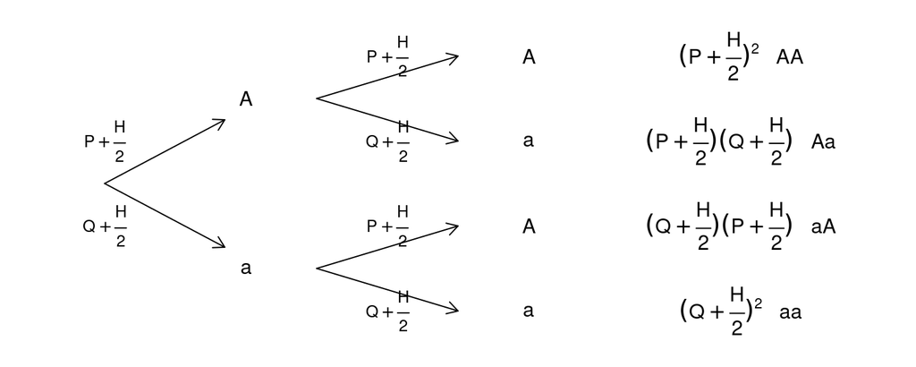

## ¿Cambian las frecuencias genotípicas?

Con reproducción aleatoria, las frecuencias de los gametos **A** y **a** son \(P+\frac{H}{2}\) y \(Q+\frac{H}{2}\), respectivamente. Tambien podemos verlo así:

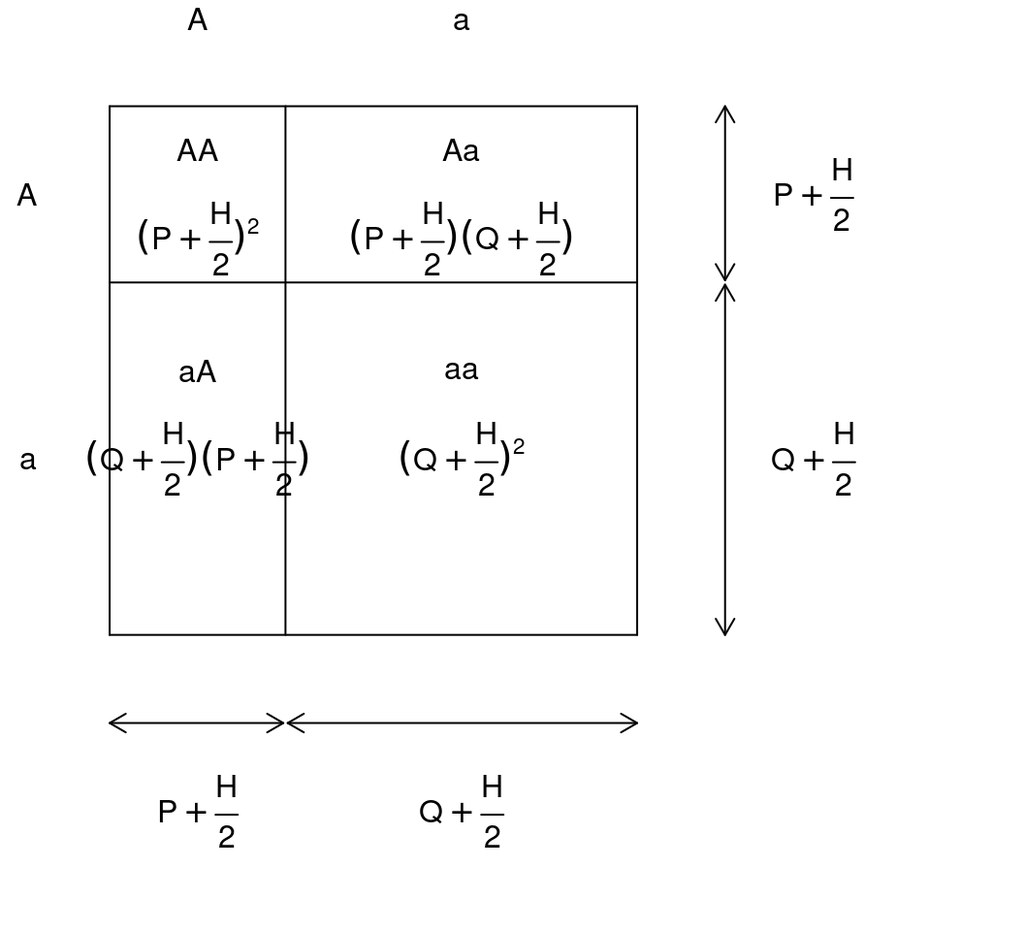

## ¿Cambian las frecuencias genotípicas?

| Padre | Madre | Frecuencia | AA | Aa | aa |
| --- | --- | --- | --- | --- | --- |
| AA | AA | \(P^2\) | \(1\) | \(0\) | \(0\) |
| AA | Aa | \(PH\) | \(\frac{1}{2}\) | \(\frac{1}{2}\) | \(0\) |
| AA | aa | \(PQ\) | \(0\) | \(1\) | \(0\) |
| Aa | AA | \(PH\) | \(\frac{1}{2}\) | \(\frac{1}{2}\) | \(0\) |
| Aa | Aa | \(H^2\) | \(\frac{1}{4}\) | \(\frac{1}{2}\) | \(\frac{1}{4}\) |
| Aa | aa | \(QH\) | \(0\) | \(\frac{1}{2}\) | \(\frac{1}{2}\) |
| aa | AA | \(PQ\) | \(0\) | \(1\) | \(0\) |
| aa | Aa | \(QH\) | \(0\) | \(\frac{1}{2}\) | \(\frac{1}{2}\) |
| aa | aa | \(Q^2\) | \(0\) | \(0\) | \(1\) |
| Total: |  | \((P+H+Q)^2=1\) | \(P'\) | \(H'\) | \(Q'\) |

\(P' = \left(P + \frac{H}{2}\right)^2, \qquad H' = 2\left(P + \frac{H}{2}\right)\left(Q + \frac{H}{2}\right), \qquad Q' = \left(Q + \frac{H}{2}\right)^2\)

## ¿Cambian las frecuencias genotípicas?

Las frecuencias genotípicas después de una generación de reproducción aleatoria serían:

\[P' = \left(P + \frac{H}{2}\right)^2\]

\[H' = 2\cdot \left(P + \frac{H}{2}\right) \cdot \left( Q+\frac{H}{2} \right)\]

\[Q' = \left(Q + \frac{H}{2}\right)^2\]

Hardy (1908) demostró (ver Apéndice) que las frecuencias genotípicas se mantienen constantes si \(H^2 = 4PQ\), lo cual es siempre cierto a partir de la segunda generación.

## Equilibrio de Hardy-Weinberg

Las frecuencias genotípicas se mantienen constantes siempre que en una población diploide:

1. La reproducción sea sexual y aleatoria (i.e., no hay consanguinidad).
2. El genotipo no afecta la probabilidad de sobrevivir o reproducirse (i.e., no hay selección natural).
3. La población es suficientemente grande (i.e., no hay deriva genética).
4. No hay inmigración.

## Frecuencias alélicas

Hubiera sido más fácil definir estas dos variables:

\[p = P + \frac{H}{2}\]

\[q = Q + \frac{H}{2}\]

Las frecuencias de los alelos **A** y **a**, respectivamente. Ahora, podemos expresar las frecuencias genotípicas después de la reproducción así:

\[P' = p^2, \qquad H' = 2pq, \qquad Q' = q^2\]

## Ejemplo

| Fenotipo | Genotipo | Frecuencia |
| --- | --- | --- |
| MM | \(L^ML^M\) | 141 |
| MN | \(L^ML^N\) | 262 |
| NN | \(L^NL^N\) | 97 |
| Total: |  | 500 |

\[p = \frac{2\times 141 + 262}{2\times 500} = 0.544\] \[q = \frac{2\times 97 + 262}{2\times 500} = 0.456\]

## Algunas conclusiones

1. La **dominancia** en sí no tiene ningúna importancia en los posibles cambios de una población a lo largo del tiempo.
2. Si la reproducción es aleatoria, las frecuencias genotípicas están determinadas por las **frecuencias alélicas**:
   - Frecuencia de homocigotos de un tipo: \(P = p^2\)
   - Frecuencia de heterocigotos: \(H = 2\cdot p\cdot q\)
   - Frecuencia de homocigotos del otro tipo: \(Q = q^2\)
3. Lo fundamental de la **evolución** son los cambios en las frecuencias alélicas.

## Con tres alelos

| Fenotipo | Genotipo | Frecuencia |
| --- | --- | --- |
| A | \(I^AI^A\) | \(p^2\) |
| AB | \(I^AI^B\) | \(2pq\) |
| A | \(I^AI^0\) | \(2pr\) |
| B | \(I^BI^B\) | \(q^2\) |
| B | \(I^BI^0\) | \(2qr\) |
| O | \(I^0I^0\) | \(r^2\) |

| Alelo | Frecuencia |
| --- | --- |
| \(I^A\) | p |
| \(I^B\) | q |
| \(I^0\) | r |

\[ p + q + r = 1\\ (p+q+r)^2 = 1\\ p^2 + 2pq + 2pr + q^2 + 2qr + r^2 = 1 \]

## En el cromosoma X

\[ p = \text{Frecuencia del alelo } X^1\\ q = \text{Frecuencia del alelo } X^2 \]

| Genotipo | Sexo | Frecuencia |
| --- | --- | --- |
| \(X^1X^1\) | hembra | \(p^2\) |
| \(X^1X^2\) | hembra | \(2pq\) |
| \(X^2X^2\) | hembra | \(q^2\) |
| \(X^1Y\) | macho | \(p\) |
| \(X^2Y\) | macho | \(q\) |

Las frecuencias genotípicas se expresan en cada sexo por separado.

## Cómo comprobar el equilibrio

Una muestra de individuos mostró los grupos sanguíneos siguientes: 114 MM, 76 MN y 10 NN (total: 200). ¿Está en equilibrio de Hardy-Weinberg esta población?

| Genotipo | Observados | Esperados | \((O-E)^2/E\) |
| --- | --- | --- | --- |
| MM | 114 |  |  |
| MN | 76 |  |  |
| NN | 10 |  |  |
|  | 200 |  |  |

Partimos de 3 datos: 3 grados de libertad, en principio. Pero…

## Cómo comprobar el equilibrio

| Genotipo | Observados | Esperados | \((O-E)^2/E\) |
| --- | --- | --- | --- |
| MM | 114 | \(N\times p^2\) |  |
| MN | 76 | \(N\times 2pq\) |  |
| NN | 10 | \(N\times q^2\) |  |
|  | 200 | \(N\) |  |

¿Cuántos parámetros necesitamos *fijar* para calcular los números *esperados*?

## Cómo comprobar el equilibrio

| Genotipo | Observados | Esperados | \((O-E)^2/E\) |
| --- | --- | --- | --- |
| MM | 114 | \(N\times p^2\) |  |
| MN | 76 | \(N\times 2pq\) |  |
| NN | 10 | \(N\times q^2\) |  |
|  | 200 | \(N\) |  |

¿Cuántos parámetros necesitamos *fijar* para calcular los números *esperados*? Sólo dos: \(N\) y \(p\) (o bien, \(N\) y \(q\)), porque \(p+q=1\). Por tanto, queda sólo \(3 - 2 = 1\) grado de libertad.

## Cómo comprobar el equilibrio

| Genotipo | Observados | Esperados | \((O-E)^2/E\) |
| --- | --- | --- | --- |
| MM | 114 | 115.52 | 0.02 |
| MN | 76 | 72.96 | 0.13 |
| NN | 10 | 11.52 | 0.20 |
|  | 200 | 200.00 | 0.35 |

\[ p = \frac{2\times 114 + 76}{2\times 200} = 0.76\\ q = \frac{76 + 2\times 10}{2\times 200} = 0.24 = 1 - p\\ \]

## Cómo comprobar el equilibrio

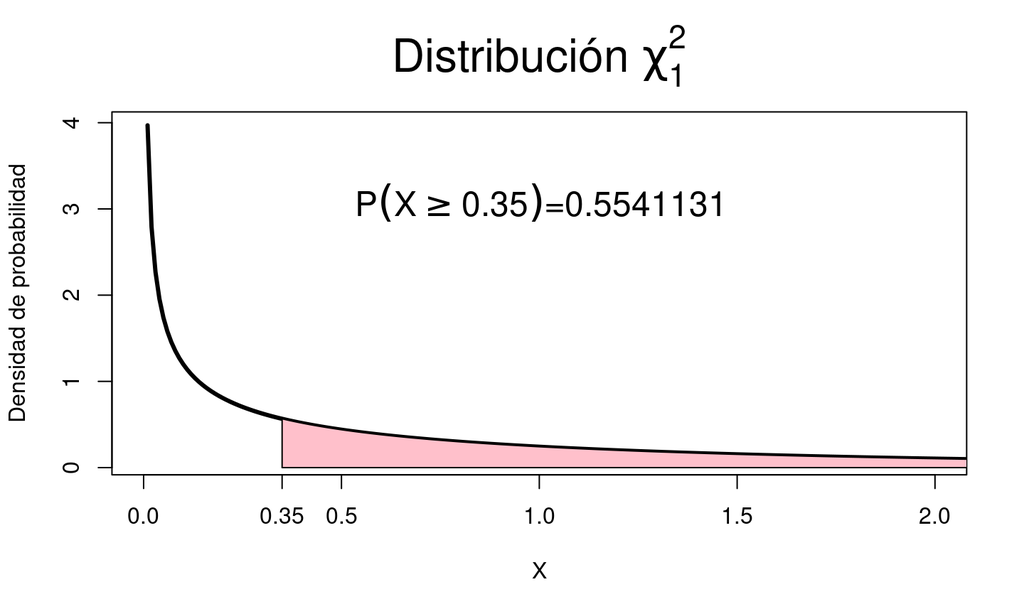

Conclusión: la población parece estar en equilibrio de Hardy-Weinberg.

## Resumen

- **Teoría**: equilibrio de Hardy-Weinberg (*HWE*): \[ P=p^2\\ H=2pq\\ Q=q^2 \]
- **Datos**: Por ejemplo: \[ N\cdot P=114\\ N\cdot H = 76\\ N\cdot Q=10 \]
- **Test**: ¿Se corresponden los datos con la esperanza teórica?

## Otras aplicaciones de la teoría

- **Teoría**: Equilibrio de Hardy-Weinberg: \(Q = q^2\), etc.
- **Datos parciales**: Por ejemplo, con dominancia: \[ N\cdot (P + H) = 190\\ N\cdot Q = 10 \]
- **Estimación**: si \(10 \simeq 200 \times q^2\), entonces \[ \hat{q} = \sqrt\frac{10}{200} \]

## Apéndice

Asumiendo reproducción aleatoria, habíamos deducido que las frecuencias genotípicas podían expresarse en función de las de la generación anterior así:

\(P' = \left(P + \frac{H}{2}\right)^2\)

\(H' = 2\cdot \left(P + \frac{H}{2}\right) \cdot \left( Q+\frac{H}{2} \right)\)

\(Q' = \left(Q + \frac{H}{2}\right)^2\)

Siguiendo el razonamiento de Hardy (1908), nos preguntamos bajo qué condiciones las frecuencias genotípicas no cambiarían, de manera que \(P'=P\), \(H'=H\) y \(Q'=Q\).

## Apéndice

La constancia de las frecuencias genotípicas implicaría lo siguiente:

\(H = 2\cdot \left(P + \frac{H}{2}\right) \cdot \left( Q+\frac{H}{2} \right)\)

\(H = 2 \left( PQ + \frac{PH}{2} + \frac{QH}{2} + \frac{H^2}{4}\right)\)

\(H = 2PQ + PH + QH + \frac{H^2}{2}\)

\(H = H(P+Q)+2PQ + \frac{H^2}{2}\)

\(H-H(P+Q)-2PQ = \frac{H^2}{2}\)

\(H(1-P-Q) - 2PQ = \frac{H^2}{2}\)

\(H^2 - 2PQ = \frac{H^2}{2} \qquad\) (Porque \(P+H+Q=1\))

\(H^2-\frac{H^2}{2} = 2PQ \qquad \rightarrow \qquad H^2 = 4PQ\)

## Apéndice

La condición \(H^2=4PQ\) no tiene por qué darse en la primera generación, pero se demuestra que en la segunda sí se da, \(H'^2 = 4P'Q'\), sea qual sea el valor de \(P\), \(H\) y \(Q\) en la primera generación:

\(H'^2 = \left(2\left( P+\frac{H}{2}\right)\left( Q+\frac{H}{2}\right)\right)^2\)

\(H'^2 = 4\left(P+\frac{H}{2}\right)^2\left( Q+\frac{H}{2}\right)^2\)

Conclusión: no hay ningún motivo para pensar que la segregación de los alelos ni la dominancia hagan cambiar las frecuencias genotípicas, siempre que la reproducción sea aleatoria.

## References

Hardy, G. H. 1908. “Mendelian Proportions in a Mixed Population.” *Science* 28: 49–50. https://doi.org/10.1126/science.28.706.49.